# Topic 7 - Classification Metrics (Abridged Version)

MSDA - MSDA7003 Machine Learning

KT Wong

Faculty of Social Sciences, HKU

2024-11-15

This is an abridged version. The materials in this topic are drawn from (Lantz 2023) and (James et al. 2023)

## Roadmap

1. Accuracy might not offer useful measure
2. Sensitivity and specificity
3. Precision, recall and F1
4. ROC curves and AUC

## Measure Performance for Classification

- we mainly measured classifier **accuracy** by dividing the number of **correct predictions** by the total number of predictions
- Consider a scenario
  - a classifier correctly predicted whether newborn babies were a carrier of a treatable but potentially fatal genetic defect in 99,990 out of 100,000 cases
    - an accuracy of **99.99%** and an error rate of only **0.01%**
  - Suppose the genetic defect is found in only **10** out of every **100,000 babies**
    - if a classifier always predicts that no baby has the defect in every case
      - it would achieve an accuracy of **99.99%** (an error rate of only **0.01%**)
      - but incorrect for 100% of the cases that matter most
      - an extremely accurate the classifier is not very useful for preventing treatable birth defects
- **class imbalance problem**
  - data having a large majority of records belonging to a single class

## A closer look at confusion matrices

- A confusion matrix is a table that categorizes predictions according to whether they match the actual value
- When the predicted value is the same as the actual value, this is a *correct classification*
  - **Correct predictions** fall on the **diagonal** in the confusion matrix (denoted by O)
  - **Incorrect predictions** fall on the **off-diagonal** matrix cells (denoted by X)
  - Performance measures for classification models are based on the counts of predictions falling on and off the diagonal in these tables

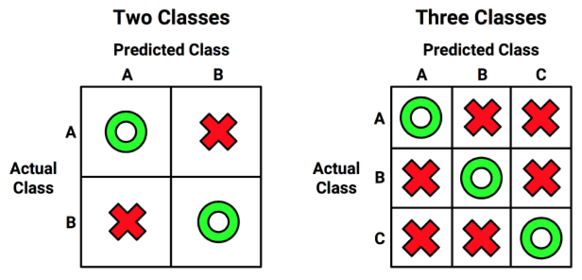

## A closer look at confusion matrices

- The most common performance measures consider the model’s ability to discern one class versus all others
- Notice that the choice of the positive outcome can be arbitrary
- Let us take a look at a $2\times2$ confusion matrix for SMS Spam example we encountered before

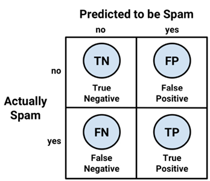

## Using confusion matrices to measure performance

- Accuracy (success rate) = $\frac{\text{TP+TN}}{\text{TP+TN+FP+FN}}$
  - error (misclassification) rate = 1 - accuracy

```r
library(tidyverse)

sms_results<- read_csv("https://raw.githubusercontent.com/kwan-MSDA/MSDA7003/main/sms_results.csv")

sms_results<- sms_results %>%
  mutate_if(is.character, as.factor)

table(sms_results$actual_type, sms_results$predict_type)
```

```
        ham spam
  ham  1203    4
  spam   31  152
```

```r
#install.packages("gmodels")
library(gmodels)

CrossTable(sms_results$actual_type, sms_results$predict_type)
```

```
   Cell Contents
|-------------------------|
|                       N |
| Chi-square contribution |
|           N / Row Total |
|           N / Col Total |
|         N / Table Total |
|-------------------------|


Total Observations in Table:  1390


                        | sms_results$predict_type
sms_results$actual_type |       ham |      spam | Row Total |
------------------------|-----------|-----------|-----------|
                    ham |      1203 |         4 |      1207 |
                        |    16.128 |   127.580 |           |
                        |     0.997 |     0.003 |     0.868 |
                        |     0.975 |     0.026 |           |
                        |     0.865 |     0.003 |           |
------------------------|-----------|-----------|-----------|
                   spam |        31 |       152 |       183 |
                        |   106.377 |   841.470 |           |
                        |     0.169 |     0.831 |     0.132 |
                        |     0.025 |     0.974 |           |
                        |     0.022 |     0.109 |           |
------------------------|-----------|-----------|-----------|
           Column Total |      1234 |       156 |      1390 |
                        |     0.888 |     0.112 |           |
------------------------|-----------|-----------|-----------|
```

```r
Acc<- (1203+152)/1390

cat("Accuracy rate = ", Acc, "\n\n")
```

```
Accuracy rate =  0.9748201
```

```r
cat("Misclassification rate = ", 1-Acc)
```

```
Misclassification rate =  0.02517986
```

## Sensitivity and specificity

- Finding a useful classifier often involves a balance between predictions that are overly conservative and overly aggressive
- Sensitivity and specificity are two performance measures that provide a more nuanced view of a classifier’s performance
- The sensitivity of a model (also called the true positive rate, recall)
  - the proportion of positive cases that were correctly classified

$$\frac{TP}{TP+FN}$$

- The specificity of a model (also called the true negative rate)
  - the proportion of negative cases that were correctly classified

$$\frac{TN}{TN+FP}$$

```r
library(caret)

sensitivity(sms_results$predict_type, sms_results$actual_type,
            positive = "spam")
```

```
[1] 0.8306011
```

```r
specificity(sms_results$predict_type, sms_results$actual_type,
            negative = "ham")
```

```
[1] 0.996686
```

## Precision

- Used primarily in the context of information retrieval, these statistics are intended to indicate
  - how interesting and relevant a model’s results are
  - or whether the predictions are diluted by meaningless noise
- The **precision** (also known as the positive predictive value) is defined as the proportion of positive predictions that are truly positive

$$\frac{TP}{TP+FP}$$

- As a comparison, sensitivity/recall (known as true positive rate) is a measure of how complete the results are
  - sensitivity/recall=$\frac{TP}{TP+FN}$

```r
library(caret)

precision<- posPredValue(sms_results$predict_type, sms_results$actual_type,
             positive="spam")


print(paste0("Precision= ", precision))
```

```
[1] "Precision= 0.974358974358975"
```

```r
sensitivity<- sensitivity(sms_results$predict_type, sms_results$actual_type,
                          positive = "spam")


print(paste0("Sensitivity= ", sensitivity))
```

```
[1] "Sensitivity= 0.830601092896175"
```

## The F-measure

- F-measure (F1 score or F-score) is a measure of model performance that combines precision and recall into a single number
  - it combines precision and recall using the harmonic mean, a type of average that is used for rates of change

$$\textrm{F-measure}=\frac{2 \times \textrm{precision} \times \textrm{recall}}{\textrm{recall} + \textrm{precision}}=\frac{2 \times TP}{2 \times TP + FP + FN}$$

- it provides a convenient, quantitative metric to compare several models directly
- it assumes that **equal weight** should be assigned to precision and recall

## Visualizing performance tradeoffs with ROC curves

- Where statistics such as sensitivity and specificity attempt to boil model performance down to a single number, visualizations depict how a learner performs across a wide range of conditions
- The receiver operating characteristic (*ROC*) curve is commonly used to examine the tradeoff between the detection of **true positives** while avoiding **false positives**
- The points comprising ROC curves indicate the true positive rate at varying false positive **thresholds**

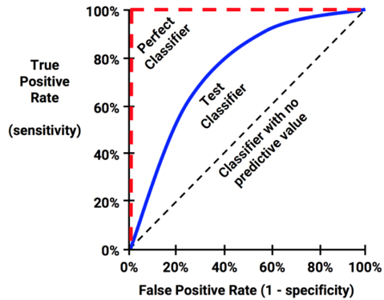

## ROC

- the perfect classifier
  - a curve passes through the point at a 100% true positive rate and a 0% false positive rate
  - correctly identify all of the true positives before it incorrectly classifies any negative result
- the diagonal line from the bottom-left to the top-right corner of the diagram represents a classifier with **no predictive value**
  - this type of classifier detects true positives and false positives at **exactly the same rate**
  - implying that the **classifier cannot discriminate between the two**
  - this is the baseline by which other classifiers may be judged
    - ROC curves falling close to this line indicate models that are not very useful
  - most real-world classifiers are like the test classifier
    - fall somewhere in the zone between perfect and useless

## ROC - An illustration

- there are 20 test cases in the dataset (6 are positive (spam) and 14 are negative (ham))

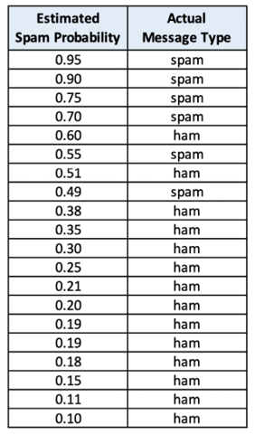

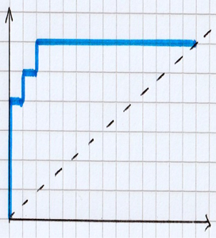

## ROC - An Illustration

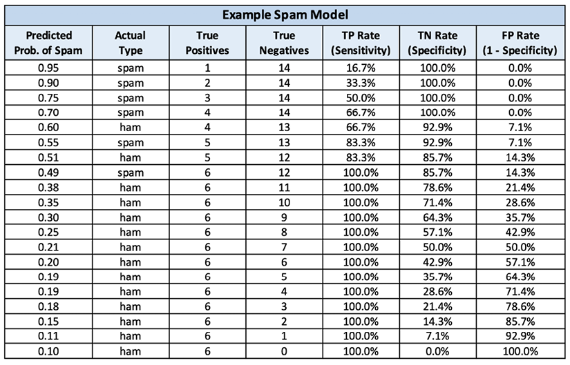

## Comparing ROC curves

- In practice, we can use ROC curves to make the comparison between models
  - however, differences between curves are often subtle, not always easy to interpret

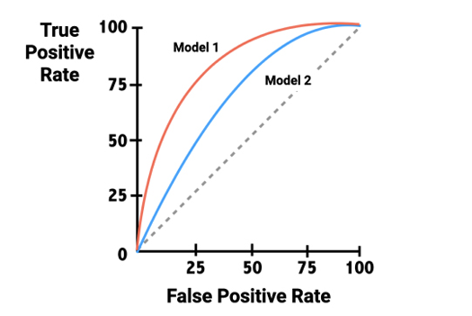

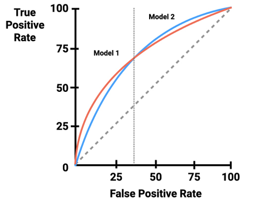

## The area under the ROC curve

- ROC curves allow model performance comparisons that also consider how the models will be used
  - This flexibility is appreciated over simpler numeric metrics like accuracy or kappa
  - it may be desirable to quantify the ROC curve in a single metric that can be compared quantitatively, much like these statistics
- the area under the ROC curve (AUC)
  - the closer the ROC curve is to the top-left of the plot, the better it is at identifying positive values
  - The AUC treats the ROC diagram as a two-dimensional square and measures the total area under the ROC curve
  - The AUC ranges from 0.5 (for a classifier with no predictive value) to 1.0 (for a perfect classifier)

## AUC

- A convention for interpreting AUC scores uses a system similar to academic letter grades:
  - A: Outstanding = 0.9 to 1.0
  - B: Excellent/Good = 0.8 to 0.9
  - C: Acceptable/Fair = 0.7 to 0.8
  - D: Poor = 0.6 to 0.7
  - E: No Discrimination = 0.5 to 0.6
- Generally speaking, higher AUC values reflect classifiers that are better at sorting a random positive case higher than a random negative case

## Creating ROC curves and computing AUC in R

- The `pROC` package provides an easy-to-use set of functions for creating ROC curves and computing the AUC

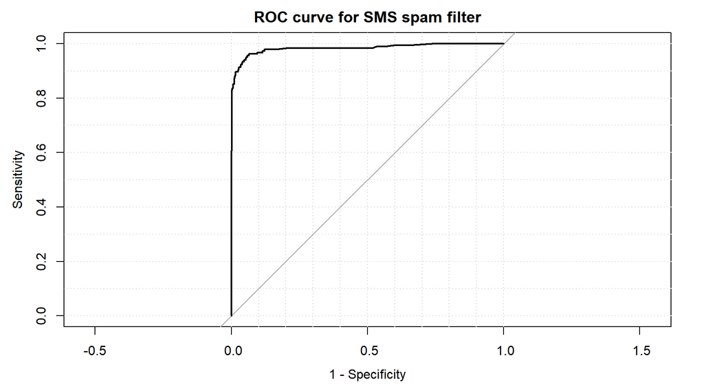

```r
#install.packages("pROC")

library(pROC)

sms_results$actual_type2<- ifelse(sms_results$actual_type=="spam",1,0)
sms_roc<- roc(sms_results$actual_type2, sms_results$prob_spam)

plot(sms_roc, main="ROC curve for SMS spam filter",
     Col='blue', lwd=2, grid=TRUE, legacy.axes=TRUE)
```

## Compare with KNN learner

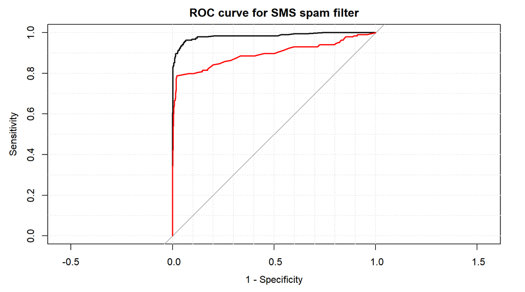

```r
library(tidyverse)

sms_results_knn<- read_csv("https://raw.githubusercontent.com/kwanto2023/Stat_UST/main/Topic%20-%20Model%20Evaluation/sms_results_knn.csv")

sms_roc_knn<- roc(sms_results$actual_type2, sms_results_knn$p_spam)

plot(sms_roc, main="ROC curve for SMS spam filter",
     Col='blue', lwd=2, grid=TRUE, legacy.axes=TRUE)

plot(sms_roc_knn, col="red", lwd=2, add=TRUE)
```

```r
auc(sms_roc)
```

```
Area under the curve: 0.9836
```

```r
auc(sms_roc_knn)
```

```
Area under the curve: 0.8942
```

## References

James, G., D. Witten, T. Hastie, and R. Tibshirani. 2023. *An Introduction to Statistical Learning with Applications in r*. Second edition. Springer.

Lantz, Brett. 2023. *Machine Learning with r : Learn Techniques for Building and Improving Machine Learning Models, from Data Preparation to Model Tuning, Evaluation, and Working with Big Data*. Fourth edition. Expert Insight. Birmingham, UK: Packt Publishing Limited.